# Final Project

Agith Antony

Life expectancy varies quite a bit throughout the United States. The map below  
demonstrates this variation. A cluster of states in the south have lower life  
expectancy, while a few states in the northeast, Minnesota, California, and  
Hawaii are at the other end of the spectrum with the highest life expectancy.

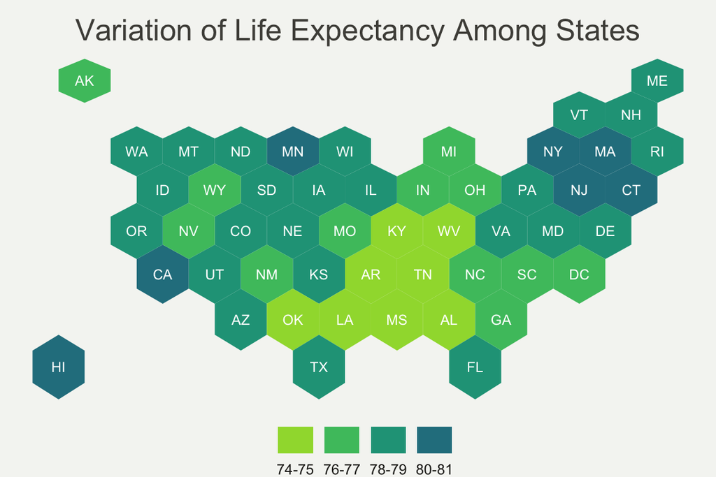

Similarly at the state level, there can be significant variation in life  
expectancy as demonstrated in the map of Illinois counties below.

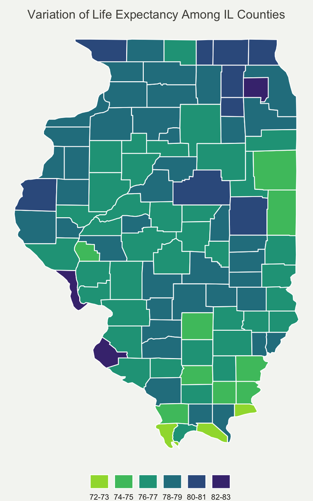

There are many factors that can contribute to life expectancy - environment,  
poverty, education, and access to healthcare.

The table below demonstrates a difference in the mean life expectancy in urban  
vs. rural counties in Illinois (this is designated by metropolitan vs non-metro  
counties).

Greater Life Expectancy in Urban IL Counties

|  | Life Expectancy |
| --- | --- |
| Metro Counties | 78.7 |
| Non-Metro Counties | 77.5 |

At least part of this discrepancy can likely be attributable to access to healthcare.  
One element of access to care is the number of providers - specifically primary  
care providers. Primary care is the typical point of access to preventative care  
which can help extend life. Primary care is typically provided by primary care  
physicians, physician assistants (PAs), or nurse practitioners (NPs).

There simply are not as many providers overall in non-metro vs metro counties as  
seen below. The gap is largest between the number of primary care physicians.  
The smaller gaps in the number of PAs and NPs suggest that these providers at  
least partly fill the larger gap of primary care physicians.

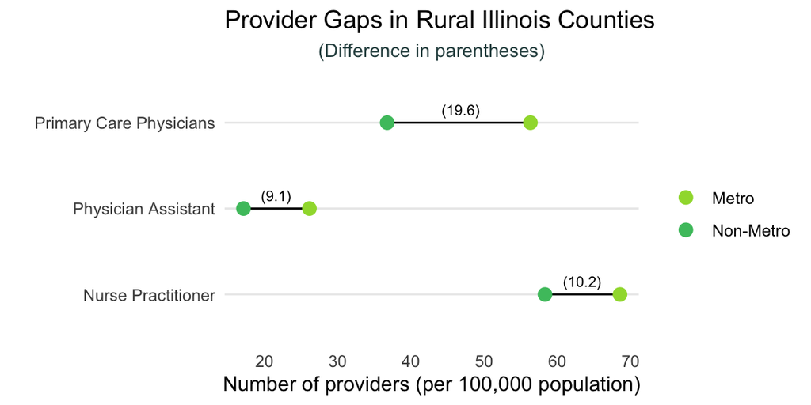

Not all providers are the same. Physicians receive more training in diagnosis and  
management of patients. There is a positive relationship between the number of  
primary care physicians and life expectancy in Illinois counties.

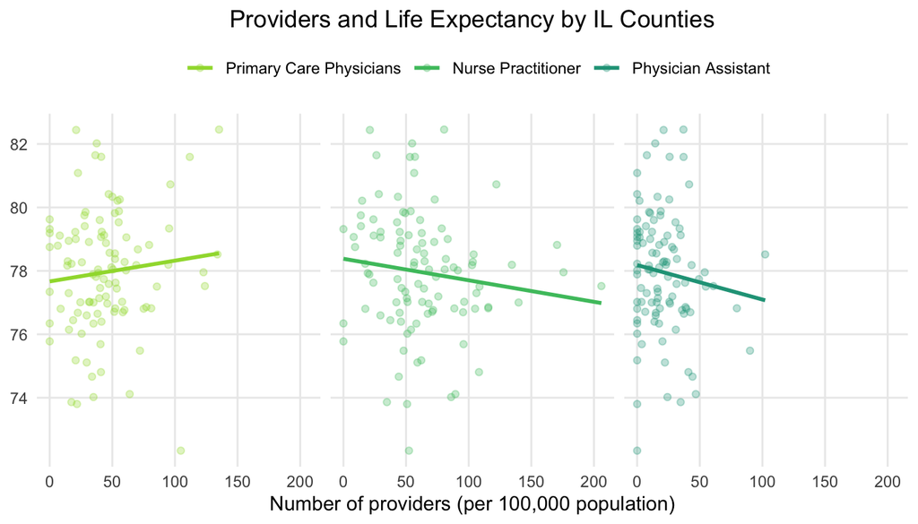

This relationship corresponds to the one seen on the national level where states  
with more primary care physicians have higher life expectancy.

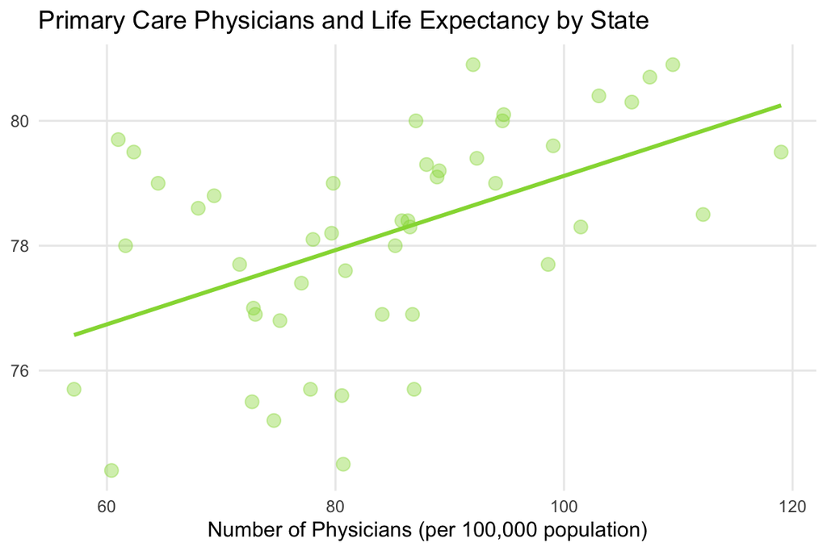

It is unclear from this data whether the positive correlation between primary  
care physicians and life expectancy is causal or representative of other factors.  
Yet, expanded access to primary care physicians could have a positive impact on  
life expectancy. This could be accomplished by incentivizing movement of physicians  
to high need areas, expanding the number of primary care physicians, or expanded  
access through technological means.

APPENDICES

1. Description of data

This dataset is from the Area Health Resources File (AHRF). It was created by the  
US Department of Health and Human Services, Health Resources and Services  
Administration, Bureau of Health Workforce (2020). It is an expansive dataset  
that provides info on the state and county level regarding the healthcare labor  
force, facilities, utilization, expenditures, as well as demographic information.  
The focus was on the healthcare professional labor force. Additionally datasets  
that provided the life expectancy of residents at the state and county (IL) level  
were used.

HRSA Data Warehouse. (2022, July). Area Health Resource Files. Health Resources  
& Services Administration. https://data.hrsa.gov/data/download?data=AHRF#AHRF

2. Intended Audience

Decision makers at the local, state and national level in government and public  
health that may potentially influence policies regarding physician practice  
location, residency slots, or other means of healthcare access.